# Available prediction performance metrics and indices

RAC measures both accuracy and precision (general agreement). Dimensionless (normalized). Bounded [0;1]. Symmetric. Robinson (1957; 1959)

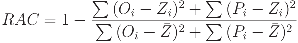

where

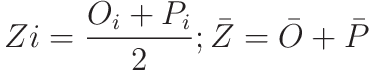

40

`AC`

Ji and Gallo’s Agreement Coefficient

AC measures both accuracy and precision (general agreement). Dimensionless (normalized). Positively bounded [-infinity;1]. Symmetric. Ji and Gallo (2006)

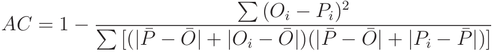

41

`lambda`

Duveiller’s Lambda Coefficient

`lambda` measures both accuracy and precision. Dimensionless (normalized). Bounded [-1;1]. Symmetric. Equivalent to CCC when `r` is greater or equal to 0. Duveiller et al. (2016)

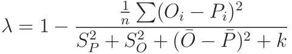

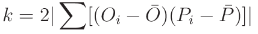

## References:

1. Correndo et al. (2021). Revisiting linear regression to test agreement in continuous predicted-observed datasets. *Agric. Syst. 192, 103194.*
2. Duveiller et al. (2016). Revisiting the concept of a symmetric index of agreement for continuous datasets. *Sci. Rep. 6, 1-14.*
3. Gupta et al. (1999). Status of automatic calibration for hydrologic models: Comparison with multilevel expert calibration. *J. Hydrologic Eng. 4(2): 135-143.*
4. Janssen & Heuberger (1995). Calibration of process-oriented models. *Ecol. Modell. 83, 55-66.*
5. Ji & Gallo (2006). An agreement coefficient for image comparison. *Photogramm. Eng. Remote Sensing 7, 823–833.*
6. Kling et al. (2012). Runoff conditions in the upper Danube basin under an ensemble of climate change scenarios. *J. Hydrol., 424-425, 264-277.*
7. Kirch (2008). Pearson’s Correlation Coefficient. *In: Kirch W. (eds) Encyclopedia of Public Health. Springer, Dordrecht.*
8. Krause et al. (2005). Comparison of different efficiency criteria for hydrological model assessment. *Adv. Geosci. 5, 89–97.*
9. Kobayashi & Salam (2000). Comparing simulated and measured values using mean squared deviation and its components. *Agron. J. 92, 345–352.*
10. Legates & McCabe (1999). Evaluating the use of “goodness-of-fit” measures in hydrologic and hydroclimatic model validation. *Water Resour. Res.*
11. Lin (1989). A concordance correlation coefficient to evaluate reproducibility. *Biometrics 45 (1), 255–268.*
12. Makridakis (1993). Accuracy measures: theoretical and practical concerns. *Int. J. Forecast. 9, 527-529.*
13. Moriasi et al. (2007). Model Evaluation Guidelines for Systematic Quantification of Accuracy in Watershed Simulations. *Trans. ASABE 50, 885–900.*
14. Nash & Sutcliffe (1970). River flow forecasting through conceptual models part I - A discussion of principles. *J. Hydrol. 10(3), 292-290.*
15. Robinson (1957). The statistical measurement of agreement. *Am. Sociol. Rev. 22(1), 17-25.*
16. Robinson (1959). The geometric interpretation of agreement. *Am. Sociol. Rev. 24(3), 338-345.*
17. Smith & Rose (1995). Model goodness-of-fit analysis using regression and related techniques. *Ecol. Model. 77, 49–64.*
18. Warton et al. (2006). Bivariate line-fitting methods for allometry. *Biol. Rev. Camb. Philos. Soc. 81, 259–291.*
19. Willmott (1981). On the validation of models. *Phys. Geogr. 2, 184–194.*
20. Willmott et al. (1985). Statistics for the evaluation and comparison of models. *J. Geophys. Res. 90, 8995.*
21. Willmott & Matsuura (2005). Advantages of the mean absolute error (MAE) over the root mean square error (RMSE) in assessing average model performance. *Clim. Res. 30, 79–82.*
22. Willmott et al. (2012). A refined index of model performance. *Int. J. Climatol. 32, 2088–2094.*
23. Yang et al. (2014). An evaluation of the statistical methods for testing the performance of crop models with observed data. *Agric. Syst. 127, 81-89.*